# Check Mapping Genotypes

DMG

8/18/2022

## Introduction

There is a genoprobs object that was used for QTL mapping. The samples are a mixture of DNA isolated from mice and cell lines. Also, some samples were repeated because they failed QC in the first batch.

Input files:

callan_genoprobs.rds: qtl2-style genoprobs object. List containing 20 items. Each item is a 3D numeric array. It contains 621 samples and 137,220 markers.

## Load Data

```r
callan = readRDS(callan_file)
divdb  = readRDS(divdb_file)
markers = read_csv(marker_file) %>%
            as.data.frame()
```

How many samples are in each data set?

```r
nrow(callan[[1]])
```

```
## [1] 621
```

```r
nrow(divdb[[1]])
```

```
## [1] 575
```

Are the sample ID’s unique in each data set?

```r
length(unique(rownames(callan[[1]])))
```

```
## [1] 621
```

```r
length(unique(rownames(divdb[[1]])))
```

```
## [1] 575
```

All of the sample IDs are unique.

How many markers are in each file?

```r
rowSums(sapply(callan, dim))[3]
```

```
## [1] 137220
```

```r
rowSums(sapply(divdb,  dim))[3]
```

```
## [1] 137220
```

They both have the same number of markers.

Are the marker IDs identical?

```r
m1 = unlist(sapply(callan, function(z) { dimnames(z)[[3]] }))
m2 = unlist(sapply(divdb,  function(z) { dimnames(z)[[3]] }))
all(m1 == m2)
```

```
## [1] TRUE
```

```r
rm(m1, m2)
```

All of the markers are in identical order.

Subset the markers to include only those being used in the data.

```r
mkrs = unlist(sapply(callan, function(z) { dimnames(z)[[3]] }))
markers = markers %>%
            filter(marker %in% mkrs) %>%
            mutate(bp_mm10 = bp_mm10 * 1e-6)
map = map_df_to_list(markers, pos_column = 'bp_mm10')
```

### Check Number of Crossovers

```r
get_xo = function(pr) {

  # Multiply by 2 and round to get 0, 1 or 2 genotypes.
  pr  = round(2 * pr)
  # Add one marker at the beginning of the probs.
  tmp = array(0L, dim = c(nrow(pr), ncol(pr), dim(pr)[3] + 1),
              dimnames = list(rownames(pr), colnames(pr), c('start', dimnames(pr)[[3]]) ))
  tmp[,,2:dim(tmp)[3]] = pr
  pr = tmp
  rm(tmp)
  # Take the difference between consecutive markers.
  pr = pr[,,2:dim(pr)[3]] - pr[,,1:(dim(pr)[3] - 1)]
  # Sum the founder columns.
  pr = apply(pr, c(1, 3), sum)
  rowSums(pr != 0)

} # get_xo()

xo1 = sapply(callan, get_xo)
xo2 = sapply(divdb,  get_xo)
```

### Filter Out High and Low Crossover Mice

```r
total_xo = c(rowSums(xo1), rowSums(xo2))
xo_mean = mean(log(total_xo))
xo_sd   = sd(log(total_xo))
ucl     = exp(xo_mean + xo_sd)
lcl     = exp(xo_mean - xo_sd)
```

```r
callan_xo = rowSums(xo1)
divdb_xo  = rowSums(xo2)

callan = callan[names(callan_xo)[callan_xo >= lcl & callan_xo <= ucl],]
divdb  = divdb[names(divdb_xo)[divdb_xo >= lcl    & divdb_xo <= ucl],]
```

## Subset Samples

Subset the samples to make sure that they are in the same order.

```r
samples = intersect(rownames(callan[[1]]), rownames(divdb[[1]]))
```

There are 529 samples in the intersection.

```r
for(i in seq_along(callan)) {
  callan[[i]] = callan[[i]][samples,,]
  divdb[[i]]  = divdb[[i]][samples,,]
} # for(i)
stopifnot(nrow(callan[[1]]) == nrow(divdb[[1]]))
```

## Convert Genoprobs to DOQTL Format

```r
mkrs = unlist(sapply(callan, function(z) { dimnames(z)[[3]] }))
tmp1 = array(0, dim = c(nrow(callan[[1]]), ncol(callan[[1]]), length(mkrs)),
             dimnames = list(rownames(callan[[1]]), colnames(callan[[1]]), mkrs))
tmp2 = array(0, dim = c(nrow(callan[[1]]), ncol(callan[[1]]), length(mkrs)),
             dimnames = list(rownames(callan[[1]]), colnames(callan[[1]]), mkrs))
chr_len = c(0, cumsum(sapply(callan, function(z) { dim(z)[3]})))

for(i in seq_along(callan)) {
  tmp1[,,(chr_len[i] + 1):chr_len[i+1]] = callan[[i]]
  tmp2[,,(chr_len[i] + 1):chr_len[i+1]] = divdb[[i]]
} # for(i)

callan = tmp1
divdb  = tmp2
rm(tmp1, tmp2)
```

## Compare Samples

For the purposes of determining whether samples are matched, I’m going to use the Pearson correlation between samples.

```r
sample_cor = setNames(rep(0, nrow(callan)), rownames(callan))

for(i in 1:nrow(callan)) {
  sample_cor[i] = cor(as.vector(callan[i,,]), as.vector(divdb[i,,]))
} # for(i)
```

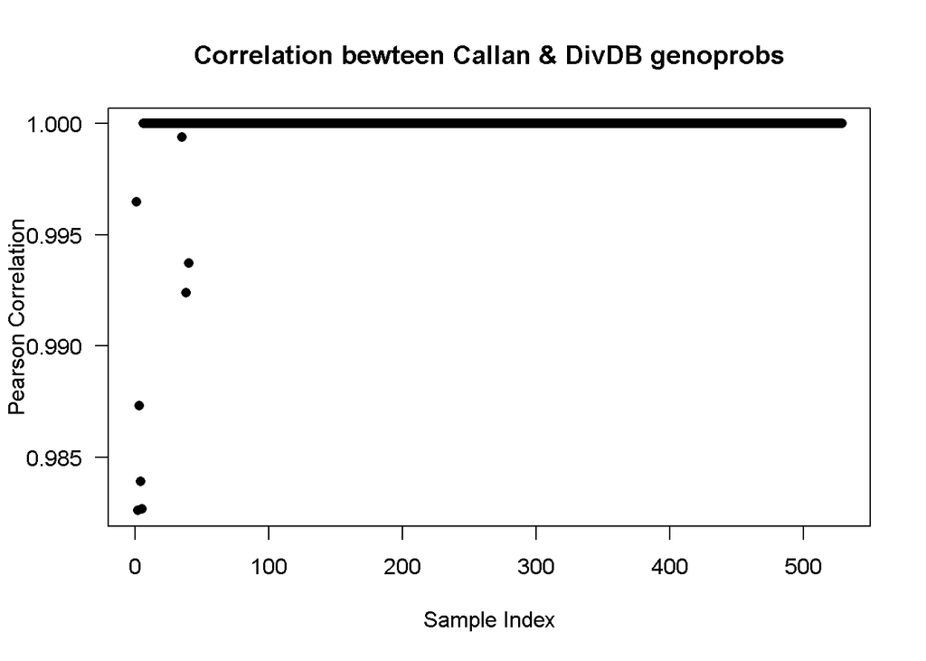

```r
plot(sample_cor, las = 1, main = 'Correlation bewteen Callan & DivDB genoprobs',
     xlab = 'Sample Index', ylab = 'Pearson Correlation', pch = 16)
```

Based on this plot, I don’t see evidence for sample mixups between the Neogen data and the genoprobs object that Callan mapped with.